# Titanic

## Analise de dados Titanic

### Cassio Philipe

Importando bibliotecas

```python
import pandas as pd
import pandas_profiling as pp
import numpy as np
import matplotlib.pyplot as plt
import seaborn as sns
from scipy.stats import mode

from sklearn.model_selection import train_test_split
from sklearn.neighbors import KNeighborsClassifier
from sklearn import preprocessing
from sklearn.ensemble import RandomForestRegressor
from sklearn.ensemble import RandomForestClassifier
from sklearn.pipeline import Pipeline
from sklearn import metrics
from sklearn.preprocessing import StandardScaler
from sklearn.preprocessing import MinMaxScaler
from sklearn.preprocessing import Normalizer
from sklearn.model_selection import GridSearchCV
from sklearn.model_selection import cross_val_predict
from sklearn.externals import joblib
```

### Introdução

O desafio consiste em predizer quais foram os passageiros que sobreviveram ao desastre do titanic, de dois datasets fornecidos nos arquivos, train.csv e test.csv.

Carregando dataset

```python
train_df = pd.read_csv('datasets/train.csv')
test_df = pd.read_csv('datasets/test.csv')
titanic = pd.read_csv('datasets/gender_submission.csv')
df_resposta = pd.DataFrame()
```

```python
train_df.tail()
```

|  | PassengerId | Survived | Pclass | Name | Sex | Age | SibSp | Parch | Ticket | Fare | Cabin | Embarked |
| --- | --- | --- | --- | --- | --- | --- | --- | --- | --- | --- | --- | --- |
| 886 | 887 | 0 | 2 | Montvila, Rev. Juozas | male | 27.0 | 0 | 0 | 211536 | 13.00 | NaN | S |
| 887 | 888 | 1 | 1 | Graham, Miss. Margaret Edith | female | 19.0 | 0 | 0 | 112053 | 30.00 | B42 | S |
| 888 | 889 | 0 | 3 | Johnston, Miss. Catherine Helen "Carrie" | female | NaN | 1 | 2 | W./C. 6607 | 23.45 | NaN | S |
| 889 | 890 | 1 | 1 | Behr, Mr. Karl Howell | male | 26.0 | 0 | 0 | 111369 | 30.00 | C148 | C |
| 890 | 891 | 0 | 3 | Dooley, Mr. Patrick | male | 32.0 | 0 | 0 | 370376 | 7.75 | NaN | Q |

### Verificar se os dados de teste estão nos dados de treinamento

```python
print(set(test_df.columns).issubset(set(train_df.columns)))
```

```
True
```

Conhecendo algums informações sobre o dataset

```python
train_df.info()
```

```
<class 'pandas.core.frame.DataFrame'>
RangeIndex: 891 entries, 0 to 890
Data columns (total 12 columns):
PassengerId    891 non-null int64
Survived       891 non-null int64
Pclass         891 non-null int64
Name           891 non-null object
Sex            891 non-null object
Age            714 non-null float64
SibSp          891 non-null int64
Parch          891 non-null int64
Ticket         891 non-null object
Fare           891 non-null float64
Cabin          204 non-null object
Embarked       889 non-null object
dtypes: float64(2), int64(5), object(5)
memory usage: 83.6+ KB
```

Com este comando conseguimos visualizar quais são as colunas disponiveis, [PassegerID (Identificação do passageiro), Survived (sobreviveu), Pclass (classe do passageiro), Name (Nome), Sex (Sexo), Age (Idade), SibSp (conjuge no navio), Parch (filhos no navio), Ticket (passagem), Fare (tarifa), Cabin (Cabine), Embarked (embarque)] e a memória utilizada na leitura/processamento do arquivo: (+ ou - 83.6KB)

```python
train_df.head()
```

|  | PassengerId | Survived | Pclass | Name | Sex | Age | SibSp | Parch | Ticket | Fare | Cabin | Embarked |
| --- | --- | --- | --- | --- | --- | --- | --- | --- | --- | --- | --- | --- |
| 0 | 1 | 0 | 3 | Braund, Mr. Owen Harris | male | 22.0 | 1 | 0 | A/5 21171 | 7.2500 | NaN | S |
| 1 | 2 | 1 | 1 | Cumings, Mrs. John Bradley (Florence Briggs Th... | female | 38.0 | 1 | 0 | PC 17599 | 71.2833 | C85 | C |
| 2 | 3 | 1 | 3 | Heikkinen, Miss. Laina | female | 26.0 | 0 | 0 | STON/O2. 3101282 | 7.9250 | NaN | S |
| 3 | 4 | 1 | 1 | Futrelle, Mrs. Jacques Heath (Lily May Peel) | female | 35.0 | 1 | 0 | 113803 | 53.1000 | C123 | S |
| 4 | 5 | 0 | 3 | Allen, Mr. William Henry | male | 35.0 | 0 | 0 | 373450 | 8.0500 | NaN | S |

```python
train_df.tail()
```

|  | PassengerId | Survived | Pclass | Name | Sex | Age | SibSp | Parch | Ticket | Fare | Cabin | Embarked |
| --- | --- | --- | --- | --- | --- | --- | --- | --- | --- | --- | --- | --- |
| 886 | 887 | 0 | 2 | Montvila, Rev. Juozas | male | 27.0 | 0 | 0 | 211536 | 13.00 | NaN | S |
| 887 | 888 | 1 | 1 | Graham, Miss. Margaret Edith | female | 19.0 | 0 | 0 | 112053 | 30.00 | B42 | S |
| 888 | 889 | 0 | 3 | Johnston, Miss. Catherine Helen "Carrie" | female | NaN | 1 | 2 | W./C. 6607 | 23.45 | NaN | S |
| 889 | 890 | 1 | 1 | Behr, Mr. Karl Howell | male | 26.0 | 0 | 0 | 111369 | 30.00 | C148 | C |
| 890 | 891 | 0 | 3 | Dooley, Mr. Patrick | male | 32.0 | 0 | 0 | 370376 | 7.75 | NaN | Q |

### Analisando os dados acima, acredito que podemos explorar na analise o seguintes campos:

#### Survived (Sobreviveu? 0 - Não / 1 - Sim)

#### Pclass (Classe: 1 - Primeira, 2 - Segunda, 3 - Terceira)

#### Age (Idade)

Conta a quantidade de linhas no dataset

```python
len(train_df)
```

```
891
```

Agora vamos verificar qual a correlação de algumas das variáveis para decidir quais serão usadas no modelo:

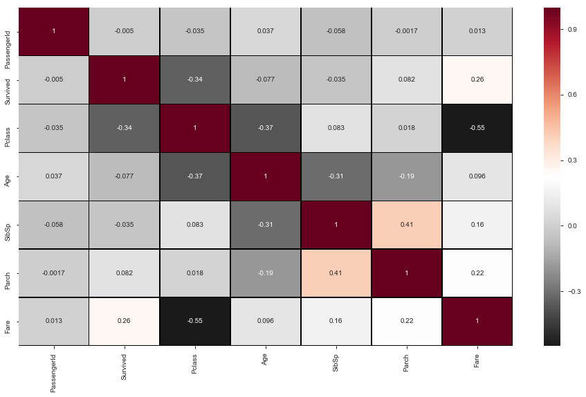

```python
%matplotlib inline

plt.figure(figsize=(16,9))
sns.heatmap(train_df.corr(), annot=True, linewidths=0.5, linecolor='black', cmap='RdGy_r')
plt.xticks(rotation=90)
plt.show()
```

```python
train_df.describe(include = "all")
```

|  | PassengerId | Survived | Pclass | Name | Sex | Age | SibSp | Parch | Ticket | Fare | Cabin | Embarked |
| --- | --- | --- | --- | --- | --- | --- | --- | --- | --- | --- | --- | --- |
| count | 891.000000 | 891.000000 | 891.000000 | 891 | 891 | 714.000000 | 891.000000 | 891.000000 | 891 | 891.000000 | 204 | 889 |
| unique | NaN | NaN | NaN | 891 | 2 | NaN | NaN | NaN | 681 | NaN | 147 | 3 |
| top | NaN | NaN | NaN | Sage, Mr. Frederick | male | NaN | NaN | NaN | CA. 2343 | NaN | B96 B98 | S |
| freq | NaN | NaN | NaN | 1 | 577 | NaN | NaN | NaN | 7 | NaN | 4 | 644 |
| mean | 446.000000 | 0.383838 | 2.308642 | NaN | NaN | 29.699118 | 0.523008 | 0.381594 | NaN | 32.204208 | NaN | NaN |
| std | 257.353842 | 0.486592 | 0.836071 | NaN | NaN | 14.526497 | 1.102743 | 0.806057 | NaN | 49.693429 | NaN | NaN |
| min | 1.000000 | 0.000000 | 1.000000 | NaN | NaN | 0.420000 | 0.000000 | 0.000000 | NaN | 0.000000 | NaN | NaN |
| 25% | 223.500000 | 0.000000 | 2.000000 | NaN | NaN | 20.125000 | 0.000000 | 0.000000 | NaN | 7.910400 | NaN | NaN |
| 50% | 446.000000 | 0.000000 | 3.000000 | NaN | NaN | 28.000000 | 0.000000 | 0.000000 | NaN | 14.454200 | NaN | NaN |
| 75% | 668.500000 | 1.000000 | 3.000000 | NaN | NaN | 38.000000 | 1.000000 | 0.000000 | NaN | 31.000000 | NaN | NaN |
| max | 891.000000 | 1.000000 | 3.000000 | NaN | NaN | 80.000000 | 8.000000 | 6.000000 | NaN | 512.329200 | NaN | NaN |

Verificando a quantidade de linhas vazias para cada coluna

```python
train_df.isnull().sum()
```

```
PassengerId      0
Survived         0
Pclass           0
Name             0
Sex              0
Age            177
SibSp            0
Parch            0
Ticket           0
Fare             0
Cabin          687
Embarked         2
dtype: int64
```

### No nosso dataset temos 891 linhas

Observei que para a idade temos 177 linhas que nao possuem idade estou supondo que a idade e importante para a sobrevivencia. Assim vou preencher a idade de forma a nao deixar vazio.

Na coluna cabine temos 687 linhas vazias, presumo que seja um dado irrelavante uma vez que temos a classe do passageiro.

```python
mode(train_df['Age']).mode[0]
```

```
24.0
```

```python
mode(test_df['Age']).mode[0]
```

```
21.0
```

```python
train_df['Age'].fillna(mode(train_df['Age']).mode[0], inplace=True)
```

```python
test_df['Age'].fillna(mode(test_df['Age']).mode[0], inplace=True)
```

Preenchendo valores vazio na tarifa

```python
train_df['Fare'].fillna(train_df['Fare'].mean(), inplace=True)
```

```python
test_df['Fare'].fillna(test_df['Fare'].mean(), inplace=True)
```

# Analise de sobrevivente dividido por classes

#### Grafico dos sobreviventes por clase

```python
print("Percentual de sobreviventes: 1 Classe:", train_df["Survived"][train_df["Pclass"] == 1].value_counts(normalize = True)[1]*100)

print("Percentual de sobreviventes: 2 Classe:", train_df["Survived"][train_df["Pclass"] == 2].value_counts(normalize = True)[1]*100)

print("Percentual de sobreviventes: 3 Classe:", train_df["Survived"][train_df["Pclass"] == 3].value_counts(normalize = True)[1]*100)
```

```
Percentual de sobreviventes: 1 Classe: 62.96296296296296
Percentual de sobreviventes: 2 Classe: 47.28260869565217
Percentual de sobreviventes: 3 Classe: 24.236252545824847
```

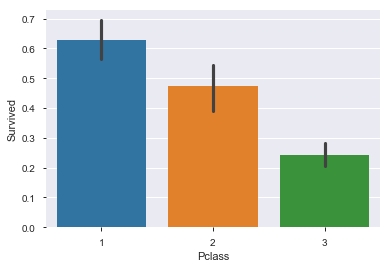

```python
sns.barplot(x="Pclass", y="Survived", data=train_df)
```

### Vamos deixas as informações mais claras removendo as informações que nao seram uteis nas analises

###### Julgamos que estas variaveis nao serao de grande impacto para nosso modelo

#### Ticket, Cabin e PassegerId

```python
train_df.drop(['Ticket','Cabin','PassengerId'], axis=1, inplace = True)
```

```python
test_df.drop(['Ticket','Cabin','PassengerId'], axis=1, inplace = True)
```

```python
train_df.head()
```

|  | Survived | Pclass | Name | Sex | Age | SibSp | Parch | Fare | Embarked |
| --- | --- | --- | --- | --- | --- | --- | --- | --- | --- |
| 0 | 0 | 3 | Braund, Mr. Owen Harris | male | 22.0 | 1 | 0 | 7.2500 | S |
| 1 | 1 | 1 | Cumings, Mrs. John Bradley (Florence Briggs Th... | female | 38.0 | 1 | 0 | 71.2833 | C |
| 2 | 1 | 3 | Heikkinen, Miss. Laina | female | 26.0 | 0 | 0 | 7.9250 | S |
| 3 | 1 | 1 | Futrelle, Mrs. Jacques Heath (Lily May Peel) | female | 35.0 | 1 | 0 | 53.1000 | S |
| 4 | 0 | 3 | Allen, Mr. William Henry | male | 35.0 | 0 | 0 | 8.0500 | S |

```python
#agora precisamos preencher os valores ausentes no recurso Embarcado
print("Number of people embarking in Southampton (S):")
southampton = train_df[train_df["Embarked"] == "S"].shape[0]
print(southampton)

print("Number of people embarking in Cherbourg (C):")
cherbourg = train_df[train_df["Embarked"] == "C"].shape[0]
print(cherbourg)

print("Number of people embarking in Queenstown (Q):")
queenstown = train_df[train_df["Embarked"] == "Q"].shape[0]
print(queenstown)
```

```
Number of people embarking in Southampton (S):
644
Number of people embarking in Cherbourg (C):
168
Number of people embarking in Queenstown (Q):
77
```

##### Como a maioria das pessoas embarcaram no portao de Southampton, vamos preencher os nulos como Southampton

```python
train_df = train_df.fillna({"Embarked": "S"})
```

```python
test_df = test_df.fillna({"Embarked": "S"})
```

```python
train_df.isnull().sum()
```

```
Survived    0
Pclass      0
Name        0
Sex         0
Age         0
SibSp       0
Parch       0
Fare        0
Embarked    0
dtype: int64
```

##### Precisamos que as variaveis Sex e Embarked sejam numericas, assim vamos deixar elas binarias

```python
train_df = pd.get_dummies(train_df, dummy_na=True, columns=['Sex','Embarked'])
```

```python
test_df = pd.get_dummies(test_df, dummy_na=True, columns=['Sex','Embarked'])
```

```python
display(train_df.head())
```

|  | Survived | Pclass | Name | Age | SibSp | Parch | Fare | Sex_female | Sex_male | Sex_nan | Embarked_C | Embarked_Q | Embarked_S | Embarked_nan |
| --- | --- | --- | --- | --- | --- | --- | --- | --- | --- | --- | --- | --- | --- | --- |
| 0 | 0 | 3 | Braund, Mr. Owen Harris | 22.0 | 1 | 0 | 7.2500 | 0 | 1 | 0 | 0 | 0 | 1 | 0 |
| 1 | 1 | 1 | Cumings, Mrs. John Bradley (Florence Briggs Th... | 38.0 | 1 | 0 | 71.2833 | 1 | 0 | 0 | 1 | 0 | 0 | 0 |
| 2 | 1 | 3 | Heikkinen, Miss. Laina | 26.0 | 0 | 0 | 7.9250 | 1 | 0 | 0 | 0 | 0 | 1 | 0 |
| 3 | 1 | 1 | Futrelle, Mrs. Jacques Heath (Lily May Peel) | 35.0 | 1 | 0 | 53.1000 | 1 | 0 | 0 | 0 | 0 | 1 | 0 |
| 4 | 0 | 3 | Allen, Mr. William Henry | 35.0 | 0 | 0 | 8.0500 | 0 | 1 | 0 | 0 | 0 | 1 | 0 |

#### Removendo Colunas Vazias

```python
train_df.drop(['Sex_nan','Embarked_nan'], axis=1, inplace = True)
```

```python
test_df.drop(['Sex_nan','Embarked_nan'], axis=1, inplace = True)
```

Agora vamos verificar qual a correlação de algumas das variáveis para decidir quais serão usadas no modelo:

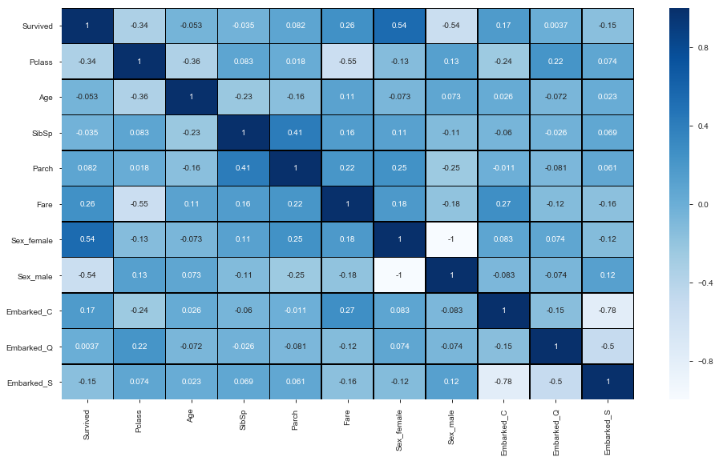

```python
%matplotlib inline

plt.figure(figsize=(16,9))
sns.heatmap(train_df.corr(), annot=True, linewidths=0.5, linecolor='black', cmap='Blues')
plt.xticks(rotation=90)
plt.show()
```

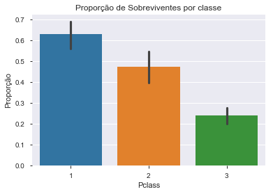

```python
#Agrupando a proporção de sobrevivente por classe e gerando um gráfico a partir do resultado

sobreviventes_classe = train_df.copy()
sobreviventes_classe['Survived'] = train_df['Survived'] == 1

sns.barplot(data=sobreviventes_classe, x="Pclass", y="Survived")

plt.title('Proporção de Sobreviventes por classe')
plt.ylabel('Proporção')
plt.show()
```

Aqui vamos adicionar a coluna de titulo usando os titulos que mais tiveram ocorrencais no nosso dataset

```python
for name_string in train_df['Name']:
    train_df['Title']=train_df['Name'].str.extract('([A-Za-z]+)\.',expand=True)



#replacing the rare title with more common one.
mapping = {'Mlle': 'Miss', 'Major': 'Mr', 'Col': 'Mr', 'Sir': 'Mr', 'Don': 'Mr', 'Mme': 'Miss',
          'Jonkheer': 'Mr', 'Lady': 'Mrs', 'Capt': 'Mr', 'Countess': 'Mrs', 'Ms': 'Miss', 'Dona': 'Mrs'}
train_df.replace({'Title': mapping}, inplace=True)

train_df['Title'].value_counts()
```

```
Mr        525
Miss      186
Mrs       127
Master     40
Dr          7
Rev         6
Name: Title, dtype: int64
```

#### Discretizando a tarifa

```python
train_df["Fare"].describe()
```

```
count    891.000000
mean      32.204208
std       49.693429
min        0.000000
25%        7.910400
50%       14.454200
75%       31.000000
max      512.329200
Name: Fare, dtype: float64
```

```python
def discrete_fare(fare):
    if np.isnan(fare):
        return fare
    elif fare <= 7.8958:
        return 0
    elif fare <= 14.4542:
        return 1
    elif fare <= 31.275:
        return 2
    else:
        return 3

train_df["Discrete_Fare"] = train_df.apply(lambda row: discrete_fare(row["Fare"]), axis=1)
train_df.head()
```

[output not shown]

```python
train_df.info()
```

[output not shown]

[figure not shown]

```python
%matplotlib inline

plt.figure(figsize=(16,9))
sns.heatmap(train_df.corr(), annot=True, linewidths=0.5, linecolor='black', cmap='Blues')
plt.xticks(rotation=90)
plt.show()
```

## Relatório de Análise Exploratória com o pandas_profiling

Vamos visualizar agora algumas informações sobre esse dataset com o pandas_profiling que facilita todo o processo de obter informações sobre o dataset:

Overview

Dataset info

| Number of variables | 14 |
| --- | --- |
| Number of observations | 891 |
| Total Missing (%) | 0.0% |
| Total size in memory | 67.1 KiB |
| Average record size in memory | 77.1 B |

Variables types

| Numeric | 6 |
| --- | --- |
| Categorical | 1 |
| Boolean | 6 |
| Date | 0 |
| Text (Unique) | 1 |
| Rejected | 0 |
| Unsupported | 0 |

Warnings

- `Discrete Fare` has 223 / 25.0% zeros Zeros

- `Fare` has 15 / 1.7% zeros Zeros

- `Parch` has 678 / 76.1% zeros Zeros

- `SibSp` has 608 / 68.2% zeros Zeros

Variables

Age  
Numeric

| Distinct count | 88 |
| --- | --- |
| Unique (%) | 9.9% |
| Missing (%) | 0.0% |
| Missing (n) | 0 |
| Infinite (%) | 0.0% |
| Infinite (n) | 0 |

| Mean | 28.567 |
| --- | --- |
| Minimum | 0.42 |
| Maximum | 80 |
| Zeros (%) | 0.0% |

Toggle details

**Statistics**

Quantile statistics

| Minimum | 0.42 |
| --- | --- |
| 5-th percentile | 6 |
| Q1 | 22 |
| Median | 24 |
| Q3 | 35 |
| 95-th percentile | 54 |
| Maximum | 80 |
| Range | 79.58 |
| Interquartile range | 13 |

Descriptive statistics

| Standard deviation | 13.2 |
| --- | --- |
| Coef of variation | 0.46206 |
| Kurtosis | 0.92266 |
| Mean | 28.567 |
| MAD | 9.9317 |
| Skewness | 0.65775 |
| Sum | 25453 |
| Variance | 174.23 |
| Memory size | 7.0 KiB |

**Histogram**

[figure not shown]

**Common Values**

| Value | Count | Frequency (%) |  |
| --- | --- | --- | --- |
| 24.0 | 207 | 23.2% |  |
| 22.0 | 27 | 3.0% |  |
| 18.0 | 26 | 2.9% |  |
| 28.0 | 25 | 2.8% |  |
| 30.0 | 25 | 2.8% |  |
| 19.0 | 25 | 2.8% |  |
| 21.0 | 24 | 2.7% |  |
| 25.0 | 23 | 2.6% |  |
| 36.0 | 22 | 2.5% |  |
| 29.0 | 20 | 2.2% |  |
| Other values (78) | 467 | 52.4% |  |

**Extreme Values**

Minimum 5 values

| Value | Count | Frequency (%) |  |
| --- | --- | --- | --- |
| 0.42 | 1 | 0.1% |  |
| 0.67 | 1 | 0.1% |  |
| 0.75 | 2 | 0.2% |  |
| 0.83 | 2 | 0.2% |  |
| 0.92 | 1 | 0.1% |  |

Maximum 5 values

| Value | Count | Frequency (%) |  |
| --- | --- | --- | --- |
| 70.0 | 2 | 0.2% |  |
| 70.5 | 1 | 0.1% |  |
| 71.0 | 2 | 0.2% |  |
| 74.0 | 1 | 0.1% |  |
| 80.0 | 1 | 0.1% |  |

Discrete Fare  
Numeric

| Distinct count | 4 |
| --- | --- |
| Unique (%) | 0.4% |
| Missing (%) | 0.0% |
| Missing (n) | 0 |
| Infinite (%) | 0.0% |
| Infinite (n) | 0 |

| Mean | 1.4893 |
| --- | --- |
| Minimum | 0 |
| Maximum | 3 |
| Zeros (%) | 25.0% |

Toggle details

**Statistics**

Quantile statistics

| Minimum | 0 |
| --- | --- |
| 5-th percentile | 0 |
| Q1 | 0.5 |
| Median | 1 |
| Q3 | 2 |
| 95-th percentile | 3 |
| Maximum | 3 |
| Range | 3 |
| Interquartile range | 1.5 |

Descriptive statistics

| Standard deviation | 1.1111 |
| --- | --- |
| Coef of variation | 0.746 |
| Kurtosis | -1.3434 |
| Mean | 1.4893 |
| MAD | 0.99155 |
| Skewness | 0.0071992 |
| Sum | 1327 |
| Variance | 1.2344 |
| Memory size | 7.0 KiB |

**Histogram**

[figure not shown]

**Common Values**

| Value | Count | Frequency (%) |  |
| --- | --- | --- | --- |
| 2 | 229 | 25.7% |  |
| 1 | 224 | 25.1% |  |
| 0 | 223 | 25.0% |  |
| 3 | 215 | 24.1% |  |

**Extreme Values**

Minimum 5 values

| Value | Count | Frequency (%) |  |
| --- | --- | --- | --- |
| 0 | 223 | 25.0% |  |
| 1 | 224 | 25.1% |  |
| 2 | 229 | 25.7% |  |
| 3 | 215 | 24.1% |  |

Maximum 5 values

| Value | Count | Frequency (%) |  |
| --- | --- | --- | --- |
| 0 | 223 | 25.0% |  |
| 1 | 224 | 25.1% |  |
| 2 | 229 | 25.7% |  |
| 3 | 215 | 24.1% |  |

Embarked_C  
Boolean

| Distinct count | 2 |
| --- | --- |
| Unique (%) | 0.2% |
| Missing (%) | 0.0% |
| Missing (n) | 0 |

| Mean | 0.18855 |
| --- | --- |

| 0 | 723 |
| --- | --- |
| 1 | 168 |

Toggle details

| Value | Count | Frequency (%) |  |
| --- | --- | --- | --- |
| 0 | 723 | 81.1% |  |
| 1 | 168 | 18.9% |  |

Embarked_Q  
Boolean

| Distinct count | 2 |
| --- | --- |
| Unique (%) | 0.2% |
| Missing (%) | 0.0% |
| Missing (n) | 0 |

| Mean | 0.08642 |
| --- | --- |

| 0 | 814 |
| --- | --- |
| 1 | 77 |

Toggle details

| Value | Count | Frequency (%) |  |
| --- | --- | --- | --- |
| 0 | 814 | 91.4% |  |
| 1 | 77 | 8.6% |  |

Embarked_S  
Boolean

| Distinct count | 2 |
| --- | --- |
| Unique (%) | 0.2% |
| Missing (%) | 0.0% |
| Missing (n) | 0 |

| Mean | 0.72503 |
| --- | --- |

| 1 | 646 |
| --- | --- |
| 0 | 245 |

Toggle details

| Value | Count | Frequency (%) |  |
| --- | --- | --- | --- |
| 1 | 646 | 72.5% |  |
| 0 | 245 | 27.5% |  |

Fare  
Numeric

| Distinct count | 248 |
| --- | --- |
| Unique (%) | 27.8% |
| Missing (%) | 0.0% |
| Missing (n) | 0 |
| Infinite (%) | 0.0% |
| Infinite (n) | 0 |

| Mean | 32.204 |
| --- | --- |
| Minimum | 0 |
| Maximum | 512.33 |
| Zeros (%) | 1.7% |

Toggle details

**Statistics**

Quantile statistics

| Minimum | 0 |
| --- | --- |
| 5-th percentile | 7.225 |
| Q1 | 7.9104 |
| Median | 14.454 |
| Q3 | 31 |
| 95-th percentile | 112.08 |
| Maximum | 512.33 |
| Range | 512.33 |
| Interquartile range | 23.09 |

Descriptive statistics

| Standard deviation | 49.693 |
| --- | --- |
| Coef of variation | 1.5431 |
| Kurtosis | 33.398 |
| Mean | 32.204 |
| MAD | 28.164 |
| Skewness | 4.7873 |
| Sum | 28694 |
| Variance | 2469.4 |
| Memory size | 7.0 KiB |

**Histogram**

[figure not shown]

**Common Values**

| Value | Count | Frequency (%) |  |
| --- | --- | --- | --- |
| 8.05 | 43 | 4.8% |  |
| 13.0 | 42 | 4.7% |  |
| 7.8958 | 38 | 4.3% |  |
| 7.75 | 34 | 3.8% |  |
| 26.0 | 31 | 3.5% |  |
| 10.5 | 24 | 2.7% |  |
| 7.925 | 18 | 2.0% |  |
| 7.775 | 16 | 1.8% |  |
| 26.55 | 15 | 1.7% |  |
| 0.0 | 15 | 1.7% |  |
| Other values (238) | 615 | 69.0% |  |

**Extreme Values**

Minimum 5 values

| Value | Count | Frequency (%) |  |
| --- | --- | --- | --- |
| 0.0 | 15 | 1.7% |  |
| 4.0125 | 1 | 0.1% |  |
| 5.0 | 1 | 0.1% |  |
| 6.2375 | 1 | 0.1% |  |
| 6.4375 | 1 | 0.1% |  |

Maximum 5 values

| Value | Count | Frequency (%) |  |
| --- | --- | --- | --- |
| 227.525 | 4 | 0.4% |  |
| 247.5208 | 2 | 0.2% |  |
| 262.375 | 2 | 0.2% |  |
| 263.0 | 4 | 0.4% |  |
| 512.3292 | 3 | 0.3% |  |

Name  
Categorical, Unique

| First 3 values |
| --- |
| Sage, Mr. Frederick |
| Kirkland, Rev. Charles Leonard |
| Henry, Miss. Delia |

| Last 3 values |
| --- |
| Christmann, Mr. Emil |
| Dowdell, Miss. Elizabeth |
| Louch, Mrs. Charles Alexander (Alice Adelaide ... |

Toggle details

First 10 values

| Value | Count | Frequency (%) |  |
| --- | --- | --- | --- |
| Abbing, Mr. Anthony | 1 | 0.1% |  |
| Abbott, Mr. Rossmore Edward | 1 | 0.1% |  |
| Abbott, Mrs. Stanton (Rosa Hunt) | 1 | 0.1% |  |
| Abelson, Mr. Samuel | 1 | 0.1% |  |
| Abelson, Mrs. Samuel (Hannah Wizosky) | 1 | 0.1% |  |

Last 10 values

| Value | Count | Frequency (%) |  |
| --- | --- | --- | --- |
| de Mulder, Mr. Theodore | 1 | 0.1% |  |
| de Pelsmaeker, Mr. Alfons | 1 | 0.1% |  |
| del Carlo, Mr. Sebastiano | 1 | 0.1% |  |
| van Billiard, Mr. Austin Blyler | 1 | 0.1% |  |
| van Melkebeke, Mr. Philemon | 1 | 0.1% |  |

Parch  
Numeric

| Distinct count | 7 |
| --- | --- |
| Unique (%) | 0.8% |
| Missing (%) | 0.0% |
| Missing (n) | 0 |
| Infinite (%) | 0.0% |
| Infinite (n) | 0 |

| Mean | 0.38159 |
| --- | --- |
| Minimum | 0 |
| Maximum | 6 |
| Zeros (%) | 76.1% |

Toggle details

**Statistics**

Quantile statistics

| Minimum | 0 |
| --- | --- |
| 5-th percentile | 0 |
| Q1 | 0 |
| Median | 0 |
| Q3 | 0 |
| 95-th percentile | 2 |
| Maximum | 6 |
| Range | 6 |
| Interquartile range | 0 |

Descriptive statistics

| Standard deviation | 0.80606 |
| --- | --- |
| Coef of variation | 2.1123 |
| Kurtosis | 9.7781 |
| Mean | 0.38159 |
| MAD | 0.58074 |
| Skewness | 2.7491 |
| Sum | 340 |
| Variance | 0.64973 |
| Memory size | 7.0 KiB |

**Histogram**

[figure not shown]

**Common Values**

| Value | Count | Frequency (%) |  |
| --- | --- | --- | --- |
| 0 | 678 | 76.1% |  |
| 1 | 118 | 13.2% |  |
| 2 | 80 | 9.0% |  |
| 5 | 5 | 0.6% |  |
| 3 | 5 | 0.6% |  |
| 4 | 4 | 0.4% |  |
| 6 | 1 | 0.1% |  |

**Extreme Values**

Minimum 5 values

| Value | Count | Frequency (%) |  |
| --- | --- | --- | --- |
| 0 | 678 | 76.1% |  |
| 1 | 118 | 13.2% |  |
| 2 | 80 | 9.0% |  |
| 3 | 5 | 0.6% |  |
| 4 | 4 | 0.4% |  |

Maximum 5 values

| Value | Count | Frequency (%) |  |
| --- | --- | --- | --- |
| 2 | 80 | 9.0% |  |
| 3 | 5 | 0.6% |  |
| 4 | 4 | 0.4% |  |
| 5 | 5 | 0.6% |  |
| 6 | 1 | 0.1% |  |

Pclass  
Numeric

| Distinct count | 3 |
| --- | --- |
| Unique (%) | 0.3% |
| Missing (%) | 0.0% |
| Missing (n) | 0 |
| Infinite (%) | 0.0% |
| Infinite (n) | 0 |

| Mean | 2.3086 |
| --- | --- |
| Minimum | 1 |
| Maximum | 3 |
| Zeros (%) | 0.0% |

Toggle details

**Statistics**

Quantile statistics

| Minimum | 1 |
| --- | --- |
| 5-th percentile | 1 |
| Q1 | 2 |
| Median | 3 |
| Q3 | 3 |
| 95-th percentile | 3 |
| Maximum | 3 |
| Range | 2 |
| Interquartile range | 1 |

Descriptive statistics

| Standard deviation | 0.83607 |
| --- | --- |
| Coef of variation | 0.36215 |
| Kurtosis | -1.28 |
| Mean | 2.3086 |
| MAD | 0.76197 |
| Skewness | -0.63055 |
| Sum | 2057 |
| Variance | 0.69902 |
| Memory size | 7.0 KiB |

**Histogram**

[figure not shown]

**Common Values**

| Value | Count | Frequency (%) |  |
| --- | --- | --- | --- |
| 3 | 491 | 55.1% |  |
| 1 | 216 | 24.2% |  |
| 2 | 184 | 20.7% |  |

**Extreme Values**

Minimum 5 values

| Value | Count | Frequency (%) |  |
| --- | --- | --- | --- |
| 1 | 216 | 24.2% |  |
| 2 | 184 | 20.7% |  |
| 3 | 491 | 55.1% |  |

Maximum 5 values

| Value | Count | Frequency (%) |  |
| --- | --- | --- | --- |
| 1 | 216 | 24.2% |  |
| 2 | 184 | 20.7% |  |
| 3 | 491 | 55.1% |  |

Sex_female  
Boolean

| Distinct count | 2 |
| --- | --- |
| Unique (%) | 0.2% |
| Missing (%) | 0.0% |
| Missing (n) | 0 |

| Mean | 0.35241 |
| --- | --- |

| 0 | 577 |
| --- | --- |
| 1 | 314 |

Toggle details

| Value | Count | Frequency (%) |  |
| --- | --- | --- | --- |
| 0 | 577 | 64.8% |  |
| 1 | 314 | 35.2% |  |

Sex_male  
Boolean

| Distinct count | 2 |
| --- | --- |
| Unique (%) | 0.2% |
| Missing (%) | 0.0% |
| Missing (n) | 0 |

| Mean | 0.64759 |
| --- | --- |

| 1 | 577 |
| --- | --- |
| 0 | 314 |

Toggle details

| Value | Count | Frequency (%) |  |
| --- | --- | --- | --- |
| 1 | 577 | 64.8% |  |
| 0 | 314 | 35.2% |  |

SibSp  
Numeric

| Distinct count | 7 |
| --- | --- |
| Unique (%) | 0.8% |
| Missing (%) | 0.0% |
| Missing (n) | 0 |
| Infinite (%) | 0.0% |
| Infinite (n) | 0 |

| Mean | 0.52301 |
| --- | --- |
| Minimum | 0 |
| Maximum | 8 |
| Zeros (%) | 68.2% |

Toggle details

**Statistics**

Quantile statistics

| Minimum | 0 |
| --- | --- |
| 5-th percentile | 0 |
| Q1 | 0 |
| Median | 0 |
| Q3 | 1 |
| 95-th percentile | 3 |
| Maximum | 8 |
| Range | 8 |
| Interquartile range | 1 |

Descriptive statistics

| Standard deviation | 1.1027 |
| --- | --- |
| Coef of variation | 2.1085 |
| Kurtosis | 17.88 |
| Mean | 0.52301 |
| MAD | 0.71378 |
| Skewness | 3.6954 |
| Sum | 466 |
| Variance | 1.216 |
| Memory size | 7.0 KiB |

**Histogram**

[figure not shown]

**Common Values**

| Value | Count | Frequency (%) |  |
| --- | --- | --- | --- |
| 0 | 608 | 68.2% |  |
| 1 | 209 | 23.5% |  |
| 2 | 28 | 3.1% |  |
| 4 | 18 | 2.0% |  |
| 3 | 16 | 1.8% |  |
| 8 | 7 | 0.8% |  |
| 5 | 5 | 0.6% |  |

**Extreme Values**

Minimum 5 values

| Value | Count | Frequency (%) |  |
| --- | --- | --- | --- |
| 0 | 608 | 68.2% |  |
| 1 | 209 | 23.5% |  |
| 2 | 28 | 3.1% |  |
| 3 | 16 | 1.8% |  |
| 4 | 18 | 2.0% |  |

Maximum 5 values

| Value | Count | Frequency (%) |  |
| --- | --- | --- | --- |
| 2 | 28 | 3.1% |  |
| 3 | 16 | 1.8% |  |
| 4 | 18 | 2.0% |  |
| 5 | 5 | 0.6% |  |
| 8 | 7 | 0.8% |  |

Survived  
Boolean

| Distinct count | 2 |
| --- | --- |
| Unique (%) | 0.2% |
| Missing (%) | 0.0% |
| Missing (n) | 0 |

| Mean | 0.38384 |
| --- | --- |

| 0 | 549 |
| --- | --- |
| 1 | 342 |

Toggle details

| Value | Count | Frequency (%) |  |
| --- | --- | --- | --- |
| 0 | 549 | 61.6% |  |
| 1 | 342 | 38.4% |  |

Title  
Categorical

| Distinct count | 6 |
| --- | --- |
| Unique (%) | 0.7% |
| Missing (%) | 0.0% |
| Missing (n) | 0 |

| Mr | 525 |
| --- | --- |
| Miss | 186 |
| Mrs | 127 |
| Other values (3) | 53 |

Toggle details

| Value | Count | Frequency (%) |  |
| --- | --- | --- | --- |
| Mr | 525 | 58.9% |  |
| Miss | 186 | 20.9% |  |
| Mrs | 127 | 14.3% |  |
| Master | 40 | 4.5% |  |
| Dr | 7 | 0.8% |  |
| Rev | 6 | 0.7% |  |

Correlations

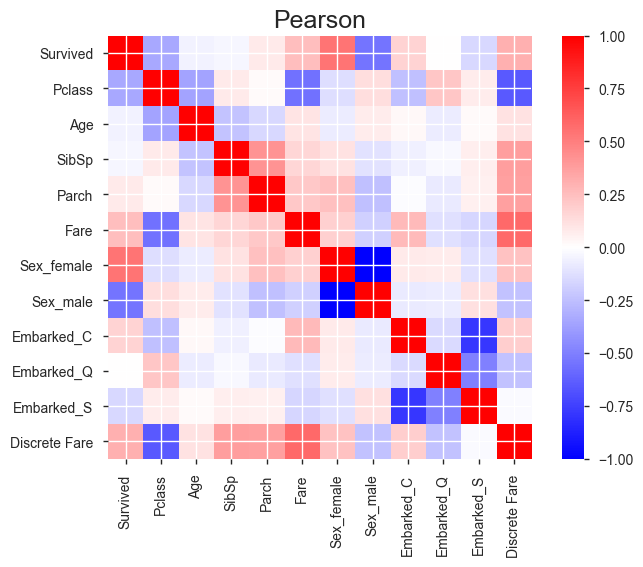

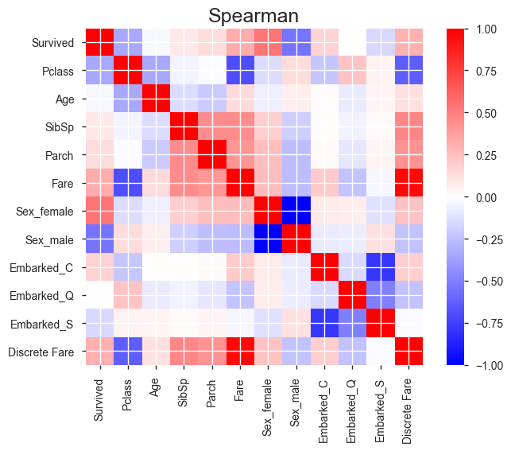

Sample

|  | Survived | Pclass | Name | Age | SibSp | Parch | Fare | Sex_female | Sex_male | Embarked_C | Embarked_Q | Embarked_S | Title | Discrete Fare |
| --- | --- | --- | --- | --- | --- | --- | --- | --- | --- | --- | --- | --- | --- | --- |
| 0 | 0 | 3 | Braund, Mr. Owen Harris | 22.0 | 1 | 0 | 7.2500 | 0 | 1 | 0 | 0 | 1 | Mr | 0 |
| 1 | 1 | 1 | Cumings, Mrs. John Bradley (Florence Briggs Th... | 38.0 | 1 | 0 | 71.2833 | 1 | 0 | 1 | 0 | 0 | Mrs | 3 |
| 2 | 1 | 3 | Heikkinen, Miss. Laina | 26.0 | 0 | 0 | 7.9250 | 1 | 0 | 0 | 0 | 1 | Miss | 1 |
| 3 | 1 | 1 | Futrelle, Mrs. Jacques Heath (Lily May Peel) | 35.0 | 1 | 0 | 53.1000 | 1 | 0 | 0 | 0 | 1 | Mrs | 3 |
| 4 | 0 | 3 | Allen, Mr. William Henry | 35.0 | 0 | 0 | 8.0500 | 0 | 1 | 0 | 0 | 1 | Mr | 1 |

```python
pp.ProfileReport(train_df)
```